# Your Digest for Saturday, Apr 27, 2024 11:59 PM

- **Pancarditis**; Pericardium, myocardium and endocardium are all affected.

[figure not shown]

- Valves affected : Mitral >>> aortic >> tricuspid > pulmonary (almost never)

[figure not shown]

> Atrophy is defined as a reduction of organ size due to a reduction in cell size and / or number. [Source](https://www.osmosis.org/learn/Atrophy%2C_aplasia%2C_and_hypoplasia)
- However, mild to moderate dysplasia **can spotaneously regress** as well. (i.e reversible)
  - 16 and 18 are high risk.
- **Treatment:** prolonged course of high dose **penicillin** / **amoxicillin** or **Co-Amoxiclav**.

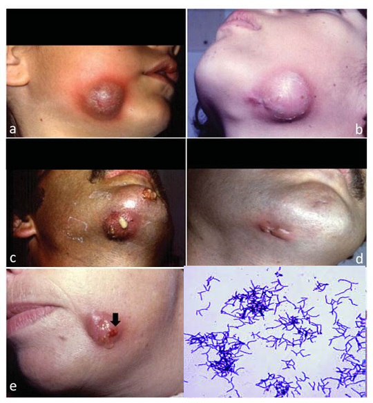

  Neurotropic virus spread by faeco-oral route **and through respiratory droplets!**
- **Vast majority are asymptomatic.**
- ⭐**non-paralytic polio** (fever, *meningismus*, headache, vomiting)
  - Acute flaccid paralysis with ⭐**pain** due to destruction of **anterior horn cells**.
  - About 66% of patients **never regain full strength**.

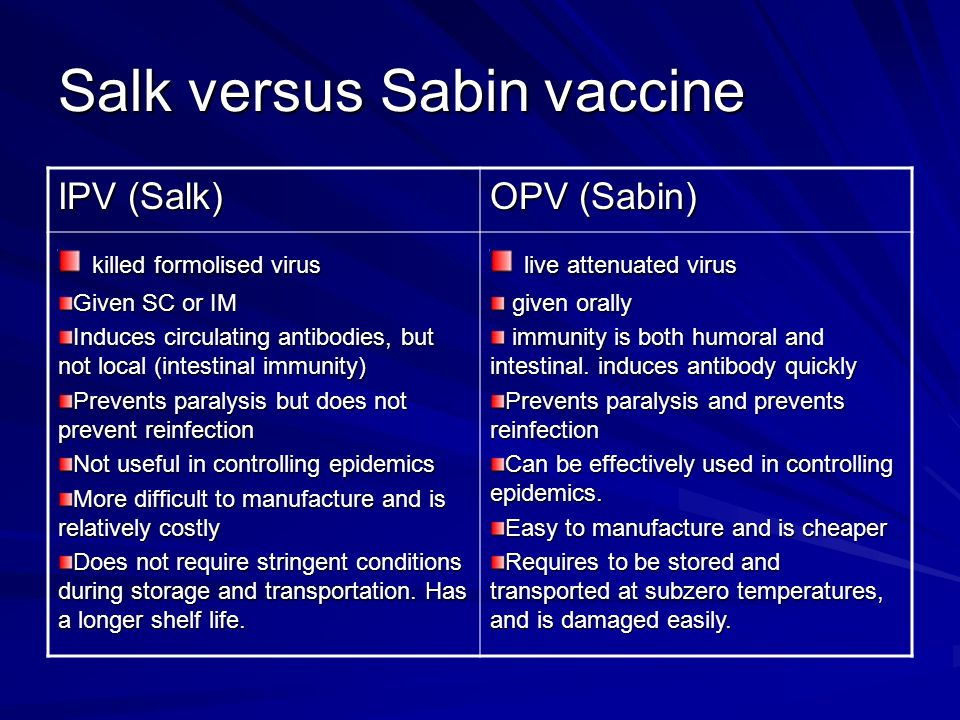

- **Inactivated vaccine (IPV)** Salk vaccine - polio virus inactivated with formaldehyde.
  - **Does not provide good mucosal immunity when compared with OPV** but it can boost immunity previously induced by OPV.
- **Live attenuated oral polio vaccine (OPV)** (Sabin vaccine)

[figure not shown]

  - OPV is being phased out in favour if IPV. (It can cause circulating vaccine-derived poliovirus (cVDPV).) [Source](https://www.who.int/news-room/questions-and-answers/item/poliomyelitis-vaccine-derived-polio)
- Pectus excavatum, scloliosis, dilation of aortic sinuses, repeated pneunothoraces, blue sclera, myopia, dural ectasia are a features. (blue sclera is seen in Marfans and Osteogenesis imperfecta ) [Source](https://my.clevelandclinic.org/health/symptoms/24766-blue-sclera)  
  Type A: Ascending aorta -> **requires surgery** to prevent aortic incompetence.
- Amoebic colitis causes "**flask shaped**" ulcers.
  - Abscesses commonly occur in **posterior right lobe** -> more commonly rupture into thorax than the abdomen.
- **Serology will not distinguish between past infection and acute infection**. (Therefore, serology is not **not very helpful in endemic areas**)
2. Echo based criteria
> - Mnemonic: the queen got chlamydia from a bartender in lagos. :P
- R/V antibiotics
- Heart drugs
- Lipids
- Genetic inheritance review - Autosomal Dominant ones
- Alcoholic hepatitis features